# Ps_Allen_Rmarkdown

## Step 2

Following the logic in Part 1, create a function that simulates data (using `simreg()` from Part 1 Step 1) and returns $b_1$ and $s_{b_1}$ (like Part 1 Step 2 did for the intercept), now using our new parameters and our `ads` vector as x. Generate 1,000 estimates of $b_1$ and corresponding $s_{b_1}$s. Calculate the corresponding $t$s. (Throughout this section, pay careful attention to where a value represents **the number of observations in a simulated dataset** and where a value represents **the number of datasets that you are simulating**. This is a distinction that has tripped students up in the past.)

#### Your knitted html does not need to include any output for this step.

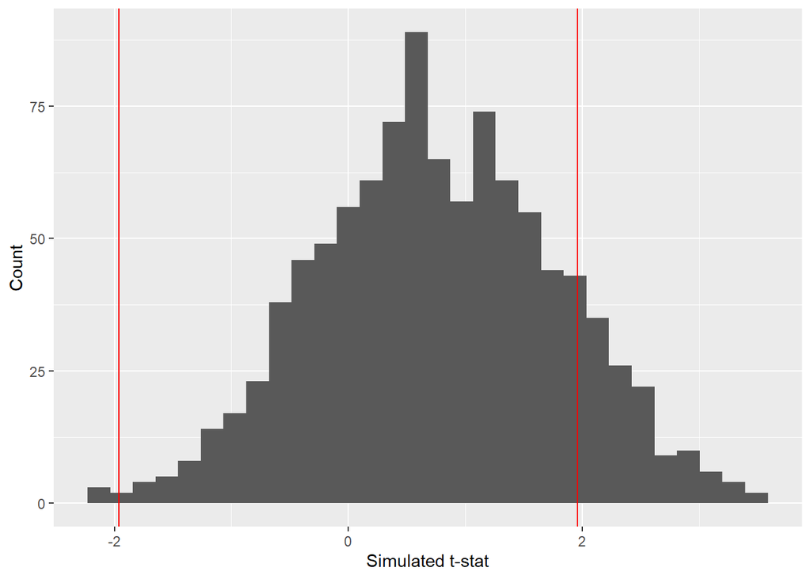

```r
simreg <- function(beta0, beta1, sigma, x){
  err <- rnorm(length(x), sd = sigma)
  beta0 + beta1 * x + err
}
gen_sample_coef <- function(beta0_to_sim, beta1_to_sim, sigma_to_sim, xs){
  ys <- simreg(beta0 = beta0_to_sim, beta1 = beta1_to_sim,
               sigma = sigma_to_sim, x = xs)
  m_sim <- lm(ys ~ xs)
  coef(summary(m_sim))[2, 1:2] # returns b_1 and s_{b_1}
}

num_samples <- 1000
truebeta0 <- 7
truebeta1 <- 0.04
truesigma <- 0.85

out_df4 <- as.data.frame(t(replicate(num_samples,
                   gen_sample_coef(beta0_to_sim = truebeta0, beta1_to_sim = truebeta1,
                                   sigma_to_sim = truesigma, xs = ads))))
colnames(out_df4) <- c("b1", "sb1")

out_df4 <- mutate(out_df4,t_stat=(b1-0)/sb1)
#p1<-qplot(out_df$t_stat,xlab="t-statistics")
ggplot(data = out_df4, aes(x = t_stat)) +
  geom_histogram() +
  xlab("Simulated t-stat") +
  ylab("Count") +
  geom_vline(xintercept = qt(.975, df = 998),color="red")+geom_vline(xintercept = qt(0.025, df = 998),color="red")
```

## Step 3

Report the proportion of samples that reject the null hypothesis that the ad campaign had no effect. This answers the question: “If the true effect of advertising were 4% lift, given $\sigma = 0.85$ and 1,000 store-days, how likely would we be to reject the null hypothesis that advertising had no effect ($H_0:\beta_1=0$)?” This is a measure of statistical power. (Remember that our degrees of freedom are no longer 434)!

#### Your knitted html should include that proportion.

```r
print("That is, on what proportion of samples did you find $|t|$ to be greater than the absolute value of the critical value calculated using 95% confidence interval?")
```

```
## [1] "That is, on what proportion of samples did you find $|t|$ to be greater than the absolute value of the critical value calculated using 95% confidence interval?"
```

```r
beyond_lim<-abs(out_df4$t_stat) > qt(.975, df = 998)
mean(beyond_lim)
```

```
## [1] 0.135
```

```r
print(paste0("we reject the null hypothesis ",mean(beyond_lim)*100,"% of the times with N=",num_samples))
```

```
## [1] "we reject the null hypothesis 13.5% of the times with N=1000"
```

## Step 4

Now vary the number of observations to see how it changes our probability of detecting an effect: try two new values of `num_obs`: 100 and 10,000. What is our statistical power in each case? For each value of N (100 and 10,000), report:  
a. The mean value of $b_1$  
b. The mean value of $s_{b_1}$  
c. The proportion of samples on which we reject the null hypothesis.

#### Your knitted html should include the values for (a), (b), and (c) for N (num_obs) = 100 and N (num_obs) = 10,000.

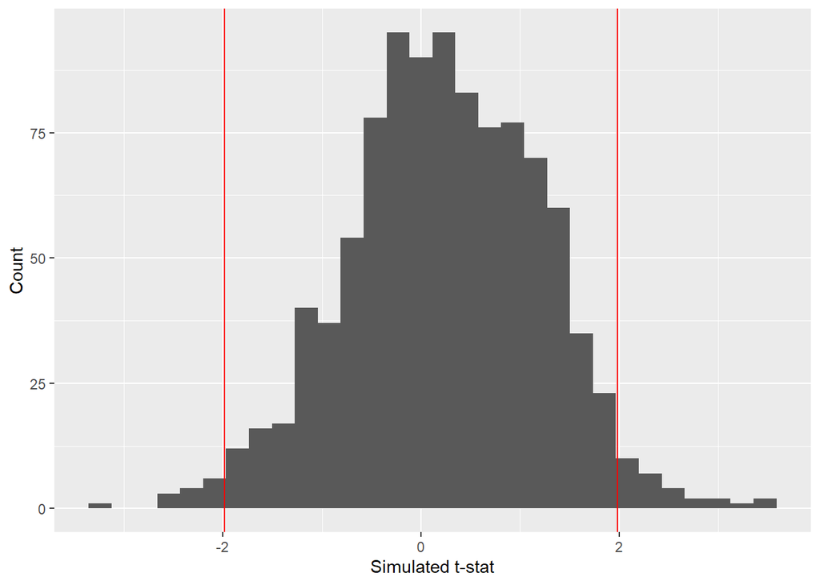

```r
num_obs <- 100
ads <- rep(c(0, 1), each = num_obs / 2) # each does 50 zeros and 50 ones. Times alternates zeros and ones.

num_samples <- 1000
truebeta0 <- 7
truebeta1 <- 0.04
truesigma <- 0.85

out_df5 <- as.data.frame(t(replicate(num_samples,
                   gen_sample_coef(beta0_to_sim = truebeta0, beta1_to_sim = truebeta1,
                                   sigma_to_sim = truesigma, xs = ads))))
colnames(out_df5) <- c("b1", "sb1")

out_df5 <- mutate(out_df5,t_stat=(b1-0)/sb1)
#p1<-qplot(out_df$t_stat,xlab="t-statistics")
ggplot(data = out_df5, aes(x = t_stat)) +
  geom_histogram() +
  xlab("Simulated t-stat") +
  ylab("Count") +
  geom_vline(xintercept = qt(.975, df = num_obs-2),color="red")+geom_vline(xintercept = qt(0.025, df = num_obs-2),color="red")
```

```r
print("That is, on what proportion of samples did you find $|t|$ to be greater than the absolute value of the critical value calculated using 95% confidence interval?")
```

```
## [1] "That is, on what proportion of samples did you find $|t|$ to be greater than the absolute value of the critical value calculated using 95% confidence interval?"
```

```r
beyond_lim<-abs(out_df5$t_stat) > qt(.975, df = num_obs-2)
mean(beyond_lim)
```

```
## [1] 0.041
```

```r
print(paste0("The mean value of b1: ",mean(out_df5$b1)))
```

```
## [1] "The mean value of b1: 0.0395634031405179"
```

```r
print(paste0("The mean value of sb1: ",mean(out_df5$sb1)))
```

```
## [1] "The mean value of sb1: 0.170103063040866"
```

```r
print(paste0("we reject the null hypothesis ",mean(beyond_lim)*100,"% of the times with number of observations N=",num_obs))
```

```
## [1] "we reject the null hypothesis 4.1% of the times with number of observations N=100"
```

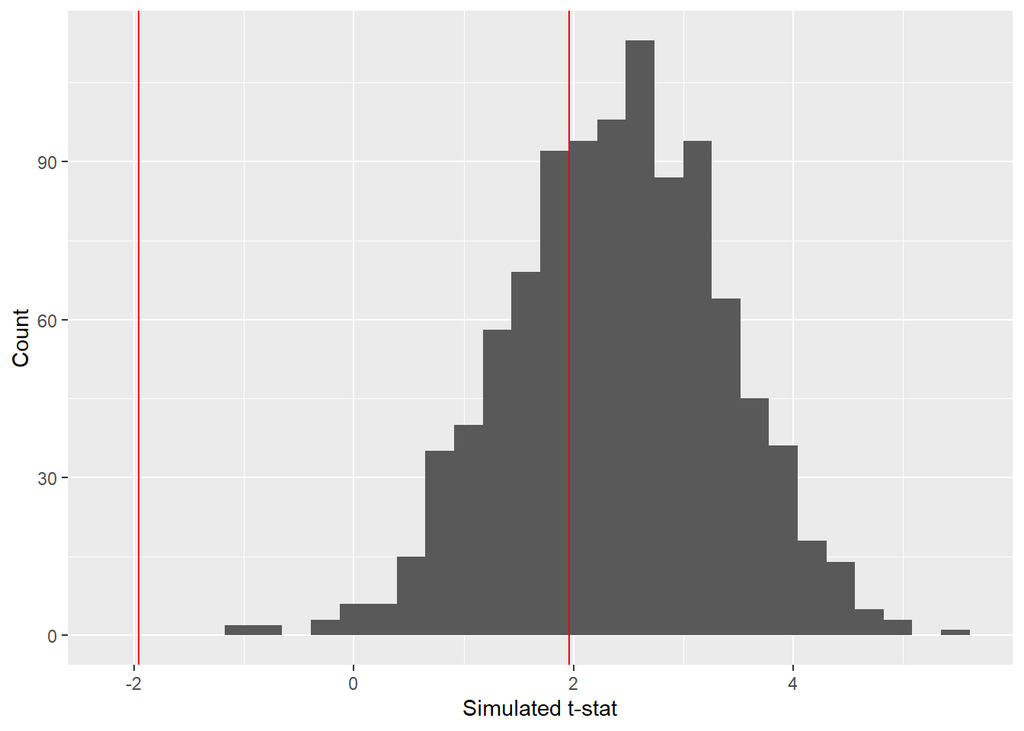

```r
num_obs <- 10000
ads <- rep(c(0, 1), each = num_obs / 2) # each does 5000 zeros and 5000 ones. Times alternates zeros and ones.
num_samples <- 1000
truebeta0 <- 7
truebeta1 <- 0.04
truesigma <- 0.85

out_df5 <- as.data.frame(t(replicate(num_samples,
                   gen_sample_coef(beta0_to_sim = truebeta0, beta1_to_sim = truebeta1,
                                   sigma_to_sim = truesigma, xs = ads))))
colnames(out_df5) <- c("b1", "sb1")

out_df5 <- mutate(out_df5,t_stat=(b1-0)/sb1)
#p1<-qplot(out_df$t_stat,xlab="t-statistics")
ggplot(data = out_df5, aes(x = t_stat)) +
  geom_histogram() +
  xlab("Simulated t-stat") +
  ylab("Count") +
  geom_vline(xintercept = qt(.975, df = num_obs-2),color="red")+geom_vline(xintercept = qt(0.025, df = num_obs-2),color="red")
```

```r
print("That is, on what proportion of samples did you find $|t|$ to be greater than the absolute value of the critical value calculated using 95% confidence interval?")
```

```
## [1] "That is, on what proportion of samples did you find $|t|$ to be greater than the absolute value of the critical value calculated using 95% confidence interval?"
```

```r
beyond_lim<-abs(out_df5$t_stat) > qt(.975, df = num_obs-2)
mean(beyond_lim)
```

```
## [1] 0.67
```

```r
print(paste0("The mean value of b1: ",mean(out_df5$b1)))
```

```
## [1] "The mean value of b1: 0.0406779609839251"
```

```r
print(paste0("The mean value of sb1: ",mean(out_df5$sb1)))
```

```
## [1] "The mean value of sb1: 0.0170051058541939"
```

```r
print(paste0("we reject the null hypothesis ",mean(beyond_lim)*100,"% of the times with number of observations N=",num_obs))
```

```
## [1] "we reject the null hypothesis 67% of the times with number of observations N=10000"
```

## Step 5

By testing different values of `num_obs`, observe what value you need to have roughly an 80% chance of rejecting the null hypothesis, in other words, 80% power. Only include that final vale of `num_obs` and simulation of 1,000 samples in the code below, though you may need to try several values to “guess and check”. Remember that each time you run this code, you’ll get a slightly different answer because you’re simulating data: if true power is .80, sometimes you’ll get .78, sometimes .81, etc., so the goal is to find a value that gives you between .75 and .85 or so, not to get *exactly* .80.

#### Your knitted html should include the value of N (num_obs) and the proportion of simulations on which you reject the null hypothesis given that value of `num_obs`.

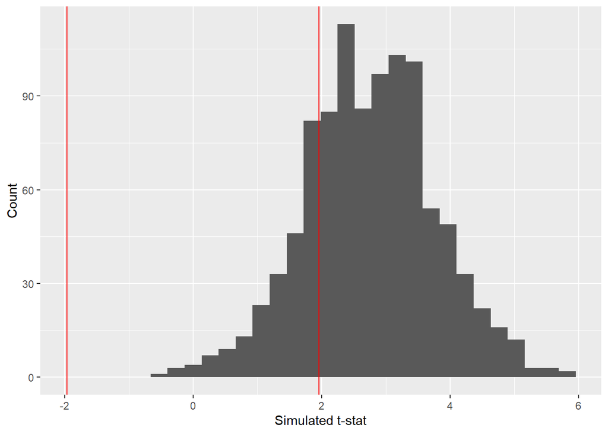

```r
num_obs <- 14200
ads <- rep(c(0, 1), each = num_obs / 2)
num_samples <- 1000
truebeta0 <- 7
truebeta1 <- 0.04
truesigma <- 0.85

out_df5 <- as.data.frame(t(replicate(num_samples,
                   gen_sample_coef(beta0_to_sim = truebeta0, beta1_to_sim = truebeta1,
                                   sigma_to_sim = truesigma, xs = ads))))
colnames(out_df5) <- c("b1", "sb1")

out_df5 <- mutate(out_df5,t_stat=(b1-0)/sb1)
#p1<-qplot(out_df$t_stat,xlab="t-statistics")
 ggplot(data = out_df5, aes(x = t_stat)) +
   geom_histogram() +
   xlab("Simulated t-stat") +
   ylab("Count") +
   geom_vline(xintercept = qt(.975, df = num_obs-2),color="red")+geom_vline(xintercept = qt(0.025, df = num_obs-2),color="red")
```

```r
#print("That is, on what proportion of samples did you find $|t|$ to be greater than the absolute value of the critical value calculated using 95% confidence interval?")
beyond_lim<-abs(out_df5$t_stat) > qt(.975, df = num_obs-2)
#mean(beyond_lim)
print(paste0("The mean value of b1: ",mean(out_df5$b1)))
```

```
## [1] "The mean value of b1: 0.039306187856563"
```

```r
print(paste0("The mean value of sb1: ",mean(out_df5$sb1)))
```

```
## [1] "The mean value of sb1: 0.0142624967588189"
```

```r
print(paste0("we reject the null hypothesis ",mean(beyond_lim)*100,"% of the times with number of observations N=",num_obs))
```

```
## [1] "we reject the null hypothesis 78.4% of the times with number of observations N=14200"
```